# The number of close relatives

# 1 Description of DataSchema variable

The description of harmonised variable is the following:

- Short name: `clsrel`
- Variable label: `The number of close relatives`
- Domain: `Social environment`
- Value type: `continuous`
- Categories:
- Category missings:

| **Code** | **Category Label** |
| --- | --- |
| 991 | CAPI/interviewer error |
| 992 | Impute |
| 993 | Disable to measure |
| 994 | Not attempt/not done |
| 995 | Does not answer |
| 996 | Not applicable |
| 997 | Refuse |
| 998 | Do not know |
| 999 | Missing |

# 2 Data process

## 2.1 England

### 2.1.1 Wave 1

#### 2.1.1.1 Study-specific variable description

The study-specific variable elected to be harmonised is:

- Name: `scfamm`
- Label: `how many of these family members would you say you have a close relat`
- Missings:
  - `-9.0 = Not answered`
  - `-8.0 = Don't know`
  - `-1.0 = Item not applicable`
- Name: `scchdm`
- Label: `how many of your children would you say you have a close relationship`
- Missings:
  - `-9.0 = Not answered`
  - `-8.0 = Don't know`
  - `-1.0 = Item not applicable`
- Description:

SCFAMM

| Sample size | Missing values |
| --- | --- |
| 12099 | 0 |

Summary

| Min. | 1st Qu. | Median | Mean | 3rd Qu. | Max. |
| --- | --- | --- | --- | --- | --- |
| -9 | -1 | 1 | 1.141 | 3 | 70 |

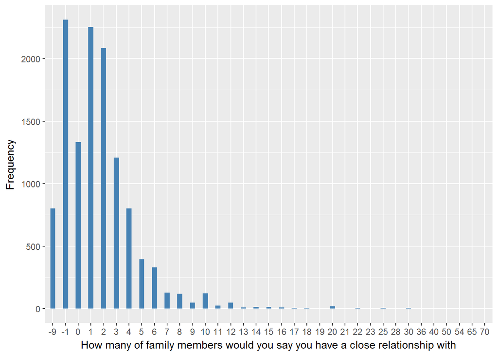

SCCHDM

| Sample size | Missing values |
| --- | --- |
| 12099 | 0 |

Summary

| Min. | 1st Qu. | Median | Mean | 3rd Qu. | Max. |
| --- | --- | --- | --- | --- | --- |
| -9 | -1 | 2 | 1.053 | 2 | 17 |

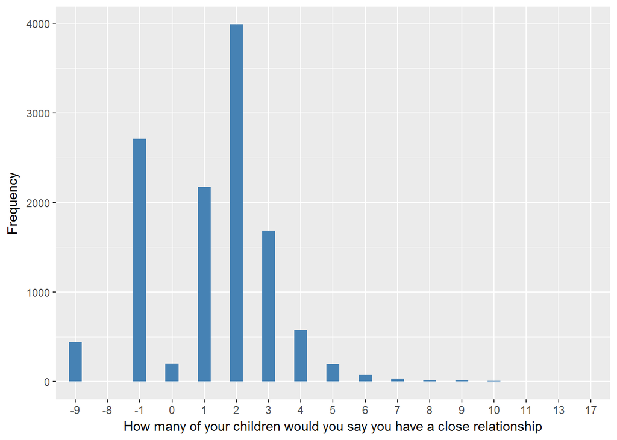

#### 2.1.1.2 Harmonisation algorithm

To compute the harmonize variable from the study-specific variable it has to be recoded as follows:

- `if scfamm>0 and scchdm>0 then clsrel = SUM of scfamm and scchdm`
- `if only one of scfamm or scchdm is >=0 then clsrel is equal to it`
- `if any equals -1 then 996`
- `if any equals -8 then 998`
- `if any equals -9 then 995`
- `NA into 999`

**R script:**

```r
ELSA_ds_w1 <- tibble(id = ELSA_w1_clsrel$id)

ELSA_w1_clsrel$scfamm <- car::recode(as.vector(ELSA_w1_clsrel$scfamm), "NA='-999'")
ELSA_w1_clsrel$scchdm <- car::recode(as.vector(ELSA_w1_clsrel$scchdm), "NA='-999'")

ELSA_ds_w1$clsrel <- c(NA)
for (i in 1:dim(ELSA_w1_clsrel)[1]) {
    if (ELSA_w1_clsrel$scfamm[i] >= 0 & ELSA_w1_clsrel$scchdm[i] >= 0) {
        ELSA_ds_w1$clsrel[i] = ELSA_w1_clsrel$scfamm[i] + ELSA_w1_clsrel$scchdm[i]
    }
    if (ELSA_w1_clsrel$scfamm[i] >= 0 & ELSA_w1_clsrel$scchdm[i] < 0) {
        ELSA_ds_w1$clsrel[i] = ELSA_w1_clsrel$scfamm[i]
    }
    if (ELSA_w1_clsrel$scfamm[i] < 0 & ELSA_w1_clsrel$scchdm[i] >= 0) {
        ELSA_ds_w1$clsrel[i] = ELSA_w1_clsrel$scchdm[i]
    } else if (ELSA_w1_clsrel$scfamm[i] == -1 & ELSA_w1_clsrel$scchdm[i] == -1) {
        ELSA_ds_w1$clsrel[i] = 996
    } else if (ELSA_w1_clsrel$scfamm[i] == -8 & ELSA_w1_clsrel$scchdm[i] == -8) {
        ELSA_ds_w1$clsrel[i] = 998
    } else if (ELSA_w1_clsrel$scfamm[i] == -9 & ELSA_w1_clsrel$scchdm[i] == -9) {
        ELSA_ds_w1$clsrel[i] = 995
    }
}

ELSA_ds_w1$clsrel <- car::recode(as.vector(ELSA_ds_w1$clsrel), "NA='999'")
ELSA_ds_w1$clsrel <- labelled(ELSA_ds_w1$clsrel, labels = c(`lack of friends` = 0,
    Missing = 999, `Do not know` = 998, Refuse = 997, `Not applicable` = 996,
    `Don't answer` = 995, `Not attempt/not done/not yet recorded` = 994, `Disable to measure` = 993,
    Impute = 992, `CAPI/interviewer error` = 991))
```

#### 2.1.1.3 Statistical description of the new harmonised variable

| Sample size | Missing values |
| --- | --- |
| 12099 | 1715 |

Values

|  | No-missings | 991 | 992 | 993 | 994 | 995 | 996 | 997 | 998 | 999 | NA |
| --- | --- | --- | --- | --- | --- | --- | --- | --- | --- | --- | --- |
| Frequency | 10384.00 | 0 | 0 | 0 | 0 | 145.0 | 1406.00 | 0 | 0 | 164.00 | 0 |
| Percentage | 85.83 | 0 | 0 | 0 | 0 | 1.2 | 11.62 | 0 | 0 | 1.36 | 0 |

Summary

| Min. | 1st Qu. | Median | Mean | 3rd Qu. | Max. |
| --- | --- | --- | --- | --- | --- |
| 0 | 2 | 3 | 4.115 | 5 | 74 |

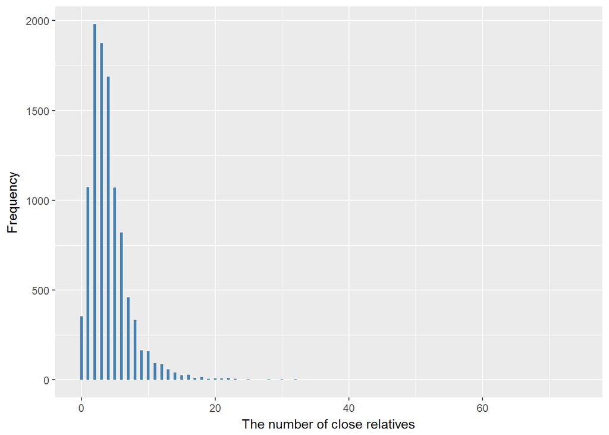

#### 2.1.1.4 Validation

### 2.1.2 Wave 2

#### 2.1.2.1 Study-specific variable description

The study-specific variable elected to be harmonised is:

- Name: `scfamm`
- Label: `how many of these family members would you say you have a close relat`
- Missings:
  - `-9.0 = Not answered`
  - `-8.0 = Don't know`
  - `-1.0 = Item not applicable`
- Name: `scchdm`
- Label: `how many of your children would you say you have a close relationship`
- Missings:
  - `-9.0 = Not answered`
  - `-8.0 = Don't know`
  - `-1.0 = Item not applicable`
- Description:

SCFAMM

| Sample size | Missing values |
| --- | --- |
| 9432 | 0 |

Summary

| Min. | 1st Qu. | Median | Mean | 3rd Qu. | Max. |
| --- | --- | --- | --- | --- | --- |
| -9 | -1 | 1 | 1.029 | 3 | 67 |

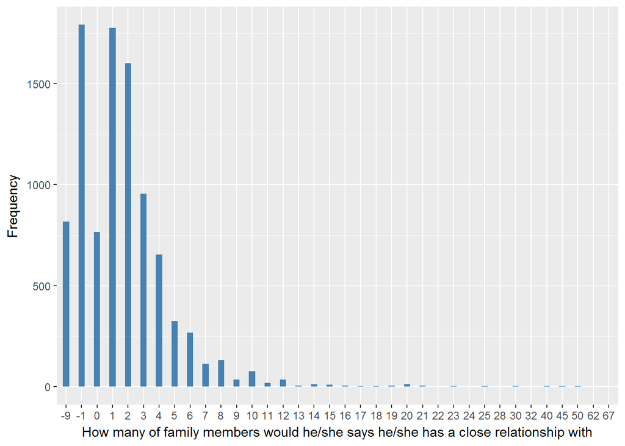

SCCHDM

| Sample size | Missing values |
| --- | --- |
| 9432 | 0 |

Summary

| Min. | 1st Qu. | Median | Mean | 3rd Qu. | Max. |
| --- | --- | --- | --- | --- | --- |
| -9 | -1 | 2 | 0.9669 | 2 | 13 |

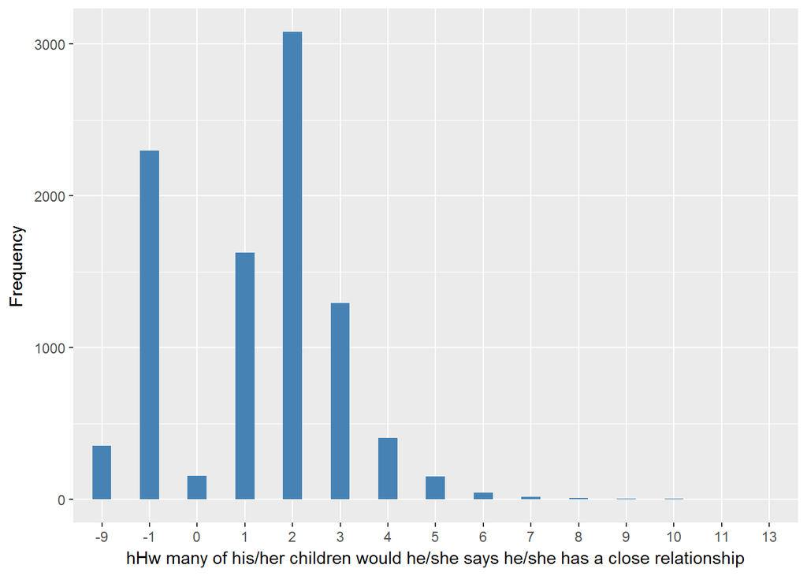

#### 2.1.2.2 Harmonisation algorithm

To recode the harmonize variable from the study-specific variable it has to be recoded as follows:

- `if scfamm>=0 and scchdm>=0 then clsrel = SUM of scfamm and scchdm`
- `if only one of scfamm or scchdm is >=0 then clsrel is equal to it`
- `if any equals -1 then 996`
- `if any equals -8 then 998`
- `if any equals -9 then 995`
- `NA into 999`

**R script:**

```r
ELSA_ds_w2 <- tibble(id = ELSA_w2_clsrel$id)

ELSA_w2_clsrel$scfamm <- car::recode(as.vector(ELSA_w2_clsrel$scfamm), "NA='-999'")
ELSA_w2_clsrel$scchdm <- car::recode(as.vector(ELSA_w2_clsrel$scchdm), "NA='-999'")

ELSA_ds_w2$clsrel <- c(NA)
for (i in 1:dim(ELSA_w2_clsrel)[1]) {
    if (ELSA_w2_clsrel$scfamm[i] >= 0 & ELSA_w2_clsrel$scchdm[i] >= 0) {
        ELSA_ds_w2$clsrel[i] = ELSA_w2_clsrel$scfamm[i] + ELSA_w2_clsrel$scchdm[i]
    }
    if (ELSA_w2_clsrel$scfamm[i] >= 0 & ELSA_w2_clsrel$scchdm[i] < 0) {
        ELSA_ds_w2$clsrel[i] = ELSA_w2_clsrel$scfamm[i]
    }
    if (ELSA_w2_clsrel$scfamm[i] < 0 & ELSA_w2_clsrel$scchdm[i] >= 0) {
        ELSA_ds_w2$clsrel[i] = ELSA_w2_clsrel$scchdm[i]
    } else if (ELSA_w2_clsrel$scfamm[i] == -1 & ELSA_w2_clsrel$scchdm[i] == -1) {
        ELSA_ds_w2$clsrel[i] = 996
    } else if (ELSA_w2_clsrel$scfamm[i] == -8 & ELSA_w2_clsrel$scchdm[i] == -8) {
        ELSA_ds_w2$clsrel[i] = 998
    } else if (ELSA_w2_clsrel$scfamm[i] == -9 & ELSA_w2_clsrel$scchdm[i] == -9) {
        ELSA_ds_w2$clsrel[i] = 995
    }
}

ELSA_ds_w2$clsrel <- car::recode(as.vector(ELSA_ds_w2$clsrel), "NA='999'")
ELSA_ds_w2$clsrel <- labelled(ELSA_ds_w2$clsrel, labels = c(`lack of friends` = 0,
    Missing = 999, `Do not know` = 998, Refuse = 997, `Not applicable` = 996,
    `Don't answer` = 995, `Not attempt/not done/not yet recorded` = 994, `Disable to measure` = 993,
    Impute = 992, `CAPI/interviewer error` = 991))
```

#### 2.1.2.3 Statistical description of the new harmonised variable

| Sample size | Missing values |
| --- | --- |
| 9432 | 1551 |

Values

|  | No-missings | 991 | 992 | 993 | 994 | 995 | 996 | 997 | 998 | 999 | NA |
| --- | --- | --- | --- | --- | --- | --- | --- | --- | --- | --- | --- |
| Frequency | 7881.00 | 0 | 0 | 0 | 0 | 152.00 | 1254.0 | 0 | 0 | 145.00 | 0 |
| Percentage | 83.56 | 0 | 0 | 0 | 0 | 1.61 | 13.3 | 0 | 0 | 1.54 | 0 |

Summary

| Min. | 1st Qu. | Median | Mean | 3rd Qu. | Max. |
| --- | --- | --- | --- | --- | --- |
| 0 | 2 | 4 | 4.242 | 5 | 69 |

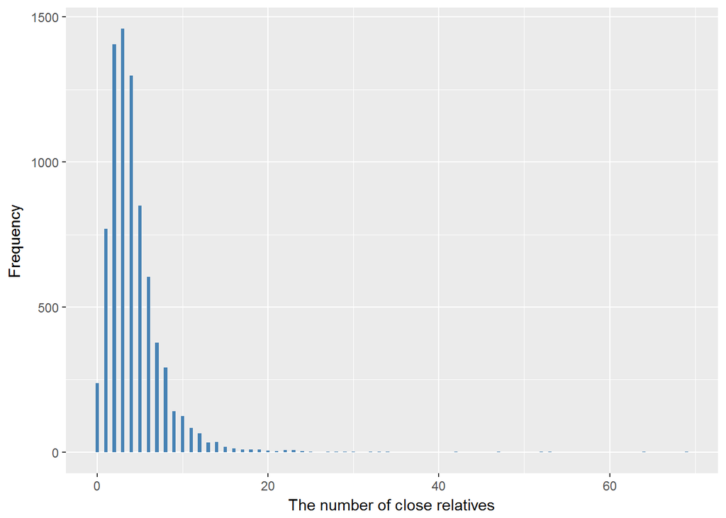

#### 2.1.2.4 Validation

### 2.1.3 Wave 3

#### 2.1.3.1 Study-specific variable description

The study-specific variable elected to be harmonised is:

- Name: `scfamm`
- Label: `how many of these family members would you say you have a close relat`
- Missings:
  - `-9.0 = Not answered`
  - `-8.0 = Don't know`
  - `-1.0 = Item not applicable`
- Name: `scchdm`
- Label: `how many of your children would you say you have a close relationship`
- Missings:
  - `-9.0 = Not answered`
  - `-8.0 = Don't know`
  - `-1.0 = Item not applicable`
- Description:

SCFAMM

| Sample size | Missing values |
| --- | --- |
| 9771 | 0 |

Summary

| Min. | 1st Qu. | Median | Mean | 3rd Qu. | Max. |
| --- | --- | --- | --- | --- | --- |
| -9 | -1 | 1 | 1.019 | 3 | 70 |

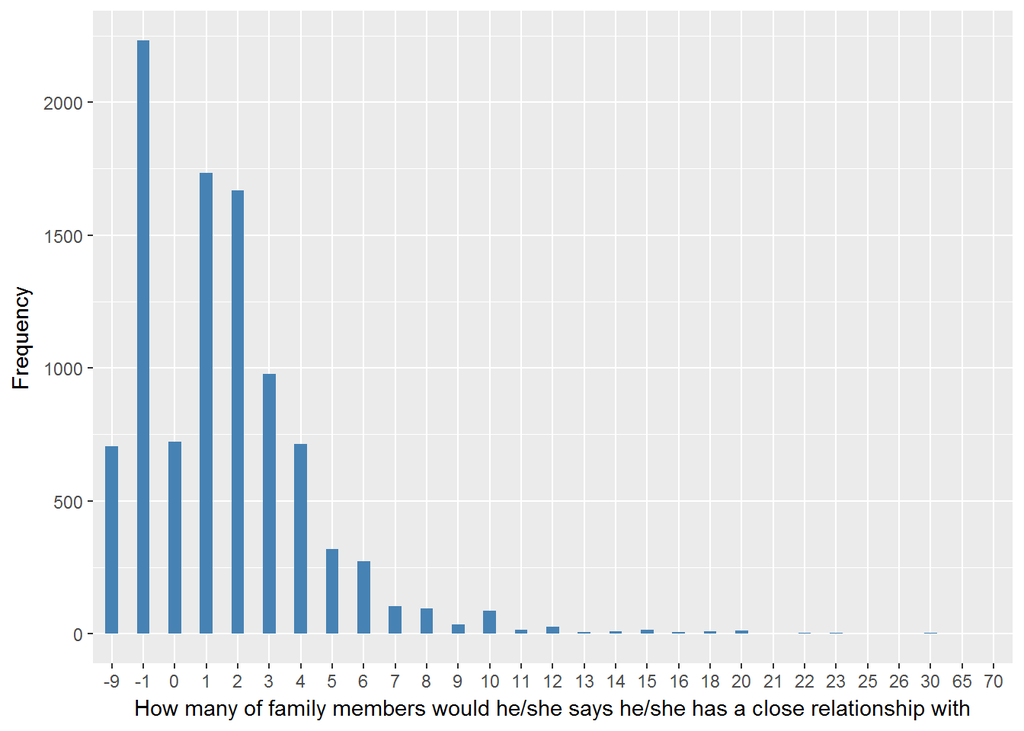

SCCHDM

| Sample size | Missing values |
| --- | --- |
| 9771 | 0 |

Summary

| Min. | 1st Qu. | Median | Mean | 3rd Qu. | Max. |
| --- | --- | --- | --- | --- | --- |
| -9 | -1 | 2 | 0.9152 | 2 | 12 |

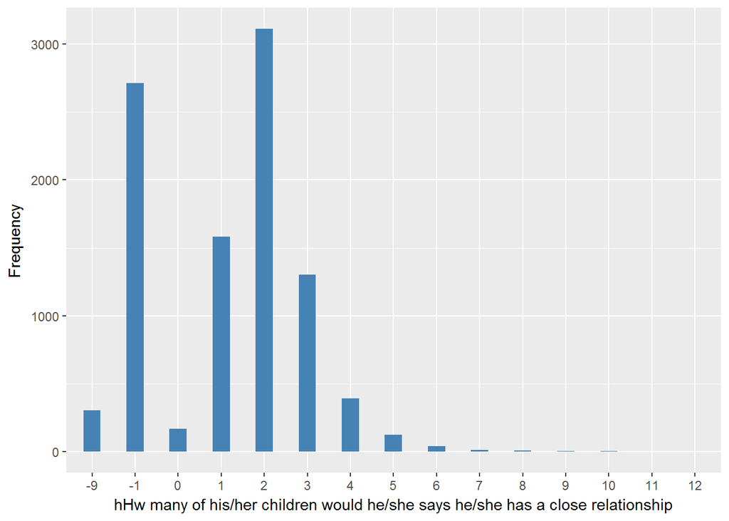

#### 2.1.3.2 Harmonisation algorithm

To recode the harmonize variable from the study-specific variable it has to be recoded as follows:

- `if scfamm>0 and scchdm>0 then clsrel = SUM of scfamm and scchdm`
- `if only one of scfamm or scchdm is >=0 then clsrel is equal to it`
- `if any equals -1 then 996`
- `if any equals -8 then 998`
- `if any equals -9 then 995`
- `NA into 999`

**R script:**

```r
ELSA_ds_w3 <- tibble(id = ELSA_w3_clsrel$id)

ELSA_w3_clsrel$scfamm <- car::recode(as.vector(ELSA_w3_clsrel$scfamm), "NA='-999'")
ELSA_w3_clsrel$scchdm <- car::recode(as.vector(ELSA_w3_clsrel$scchdm), "NA='-999'")

ELSA_ds_w3$clsrel <- c(NA)
for (i in 1:dim(ELSA_w3_clsrel)[1]) {
    if (ELSA_w3_clsrel$scfamm[i] >= 0 & ELSA_w3_clsrel$scchdm[i] >= 0) {
        ELSA_ds_w3$clsrel[i] = ELSA_w3_clsrel$scfamm[i] + ELSA_w3_clsrel$scchdm[i]
    }
    if (ELSA_w3_clsrel$scfamm[i] >= 0 & ELSA_w3_clsrel$scchdm[i] < 0) {
        ELSA_ds_w3$clsrel[i] = ELSA_w3_clsrel$scfamm[i]
    }
    if (ELSA_w3_clsrel$scfamm[i] < 0 & ELSA_w3_clsrel$scchdm[i] >= 0) {
        ELSA_ds_w3$clsrel[i] = ELSA_w3_clsrel$scchdm[i]
    } else if (ELSA_w3_clsrel$scfamm[i] == -1 & ELSA_w3_clsrel$scchdm[i] == -1) {
        ELSA_ds_w3$clsrel[i] = 996
    } else if (ELSA_w3_clsrel$scfamm[i] == -8 & ELSA_w3_clsrel$scchdm[i] == -8) {
        ELSA_ds_w3$clsrel[i] = 998
    } else if (ELSA_w3_clsrel$scfamm[i] == -9 & ELSA_w3_clsrel$scchdm[i] == -9) {
        ELSA_ds_w3$clsrel[i] = 995
    }
}

ELSA_ds_w3$clsrel <- car::recode(as.vector(ELSA_ds_w3$clsrel), "NA='999'")
ELSA_ds_w3$clsrel <- labelled(ELSA_ds_w3$clsrel, labels = c(`lack of friends` = 0,
    Missing = 999, `Do not know` = 998, Refuse = 997, `Not applicable` = 996,
    `Don't answer` = 995, `Not attempt/not done/not yet recorded` = 994, `Disable to measure` = 993,
    Impute = 992, `CAPI/interviewer error` = 991))
```

#### 2.1.3.3 Statistical description of the new harmonised variable

| Sample size | Missing values |
| --- | --- |
| 9771 | 1935 |

Values

|  | No-missings | 991 | 992 | 993 | 994 | 995 | 996 | 997 | 998 | 999 | NA |
| --- | --- | --- | --- | --- | --- | --- | --- | --- | --- | --- | --- |
| Frequency | 7836.0 | 0 | 0 | 0 | 0 | 119.00 | 1702.00 | 0 | 0 | 114.00 | 0 |
| Percentage | 80.2 | 0 | 0 | 0 | 0 | 1.22 | 17.42 | 0 | 0 | 1.17 | 0 |

Summary

| Min. | 1st Qu. | Median | Mean | 3rd Qu. | Max. |
| --- | --- | --- | --- | --- | --- |
| 0 | 2 | 4 | 4.203 | 5 | 72 |

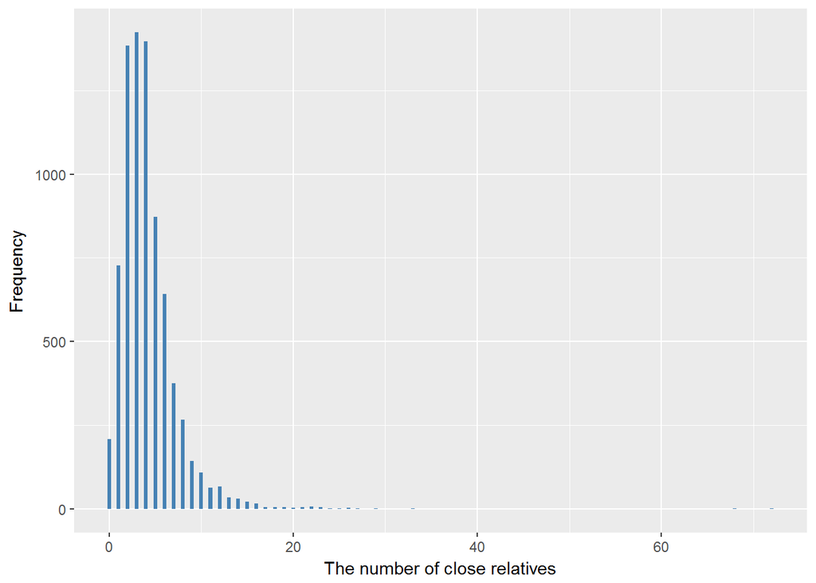

#### 2.1.3.4 Validation

### 2.1.4 Wave 4

#### 2.1.4.1 Study-specific variable description

The study-specific variable elected to be harmonised is:

- Name: `scfamm`
- Label: `how many of these family members would you say you have a close relat`
- Missings:
  - `-9.0 = Not answered`
  - `-8.0 = Don't know`
  - `-1.0 = Item not applicable`
- Name: `scchdm`
- Label: `how many of your children would you say you have a close relationship`
- Missings:
  - `-9.0 = Not answered`
  - `-8.0 = Don't know`
  - `-1.0 = Item not applicable`
- Description:

SCFAMM

| Sample size | Missing values |
| --- | --- |
| 11050 | 0 |

Summary

| Min. | 1st Qu. | Median | Mean | 3rd Qu. | Max. |
| --- | --- | --- | --- | --- | --- |
| -9 | -1 | 1 | 1.09 | 3 | 71 |

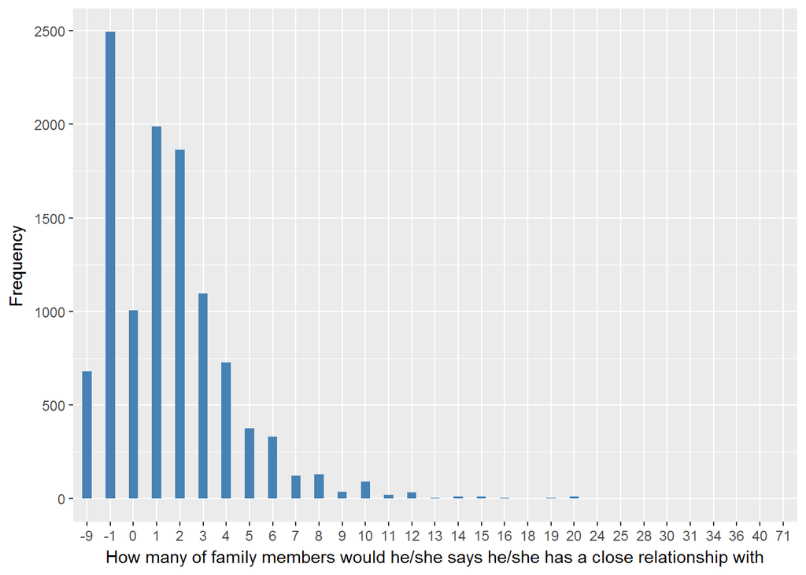

SCCHDM

| Sample size | Missing values |
| --- | --- |
| 11050 | 0 |

Summary

| Min. | 1st Qu. | Median | Mean | 3rd Qu. | Max. |
| --- | --- | --- | --- | --- | --- |
| -9 | -1 | 2 | 0.969 | 2 | 11 |

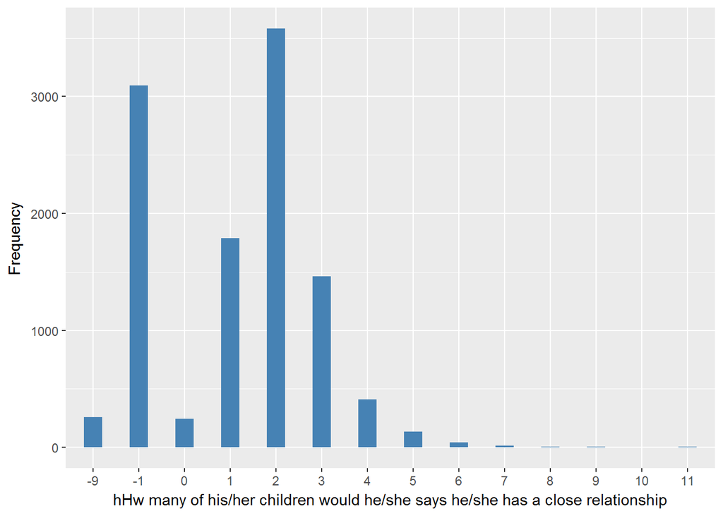

#### 2.1.4.2 Harmonisation algorithm

To recode the harmonize variable from the study-specific variable it has to be recoded as follows:

- `if scfamm>0 and scchdm>0 then clsrel = SUM of scfamm and scchdm`
- `if only one of scfamm or scchdm is >=0 then clsrel is equal to it`
- `if any equals -1 then 996`
- `if any equals -8 then 998`
- `if any equals -9 then 995`
- `NA into 999`

**R script:**

```r
ELSA_ds_w4 <- tibble(id = ELSA_w4_clsrel$id)

ELSA_w4_clsrel$scfamm <- car::recode(as.vector(ELSA_w4_clsrel$scfamm), "NA='-999'")
ELSA_w4_clsrel$scchdm <- car::recode(as.vector(ELSA_w4_clsrel$scchdm), "NA='-999'")

ELSA_ds_w4$clsrel <- c(NA)
for (i in 1:dim(ELSA_w4_clsrel)[1]) {
    if (ELSA_w4_clsrel$scfamm[i] >= 0 & ELSA_w4_clsrel$scchdm[i] >= 0) {
        ELSA_ds_w4$clsrel[i] = ELSA_w4_clsrel$scfamm[i] + ELSA_w4_clsrel$scchdm[i]
    }
    if (ELSA_w4_clsrel$scfamm[i] >= 0 & ELSA_w4_clsrel$scchdm[i] < 0) {
        ELSA_ds_w4$clsrel[i] = ELSA_w4_clsrel$scfamm[i]
    }
    if (ELSA_w4_clsrel$scfamm[i] < 0 & ELSA_w4_clsrel$scchdm[i] >= 0) {
        ELSA_ds_w4$clsrel[i] = ELSA_w4_clsrel$scchdm[i]
    } else if (ELSA_w4_clsrel$scfamm[i] == -1 & ELSA_w4_clsrel$scchdm[i] == -1) {
        ELSA_ds_w4$clsrel[i] = 996
    } else if (ELSA_w4_clsrel$scfamm[i] == -8 & ELSA_w4_clsrel$scchdm[i] == -8) {
        ELSA_ds_w4$clsrel[i] = 998
    } else if (ELSA_w4_clsrel$scfamm[i] == -9 & ELSA_w4_clsrel$scchdm[i] == -9) {
        ELSA_ds_w4$clsrel[i] = 995
    }
}

ELSA_ds_w4$clsrel <- car::recode(as.vector(ELSA_ds_w4$clsrel), "NA='999'")
ELSA_ds_w4$clsrel <- labelled(ELSA_ds_w4$clsrel, labels = c(`lack of friends` = 0,
    Missing = 999, `Do not know` = 998, Refuse = 997, `Not applicable` = 996,
    `Don't answer` = 995, `Not attempt/not done/not yet recorded` = 994, `Disable to measure` = 993,
    Impute = 992, `CAPI/interviewer error` = 991))
```

#### 2.1.4.3 Statistical description of the new harmonised variable

| Sample size | Missing values |
| --- | --- |
| 11050 | 2108 |

Values

|  | No-missings | 991 | 992 | 993 | 994 | 995 | 996 | 997 | 998 | 999 | NA |
| --- | --- | --- | --- | --- | --- | --- | --- | --- | --- | --- | --- |
| Frequency | 8942.00 | 0 | 0 | 0 | 0 | 96.00 | 1897.00 | 0 | 0 | 115.00 | 0 |
| Percentage | 80.92 | 0 | 0 | 0 | 0 | 0.87 | 17.17 | 0 | 0 | 1.04 | 0 |

Summary

| Min. | 1st Qu. | Median | Mean | 3rd Qu. | Max. |
| --- | --- | --- | --- | --- | --- |
| 0 | 2 | 4 | 4.114 | 5 | 74 |

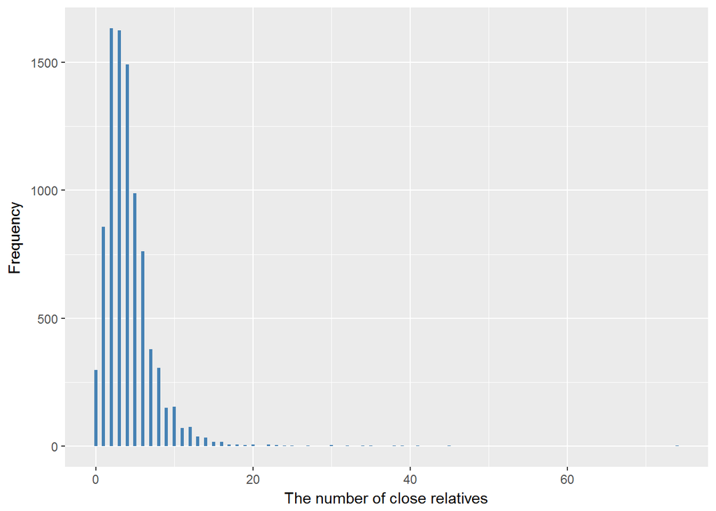

#### 2.1.4.4 Validation

### 2.1.5 Wave 5

#### 2.1.5.1 Study-specific variable description

The study-specific variable elected to be harmonised is:

- Name: `scfamm`
- Label: `how many of these family members would you say you have a close relat`
- Missings:
  - `-9.0 = Not answered`
  - `-8.0 = Don't know`
  - `-1.0 = Item not applicable`
- Name: `scchdm`
- Label: `how many of your children would you say you have a close relationship`
- Missings:
  - `-9.0 = Not answered`
  - `-8.0 = Don't know`
  - `-1.0 = Item not applicable`
- Description:

SCFAMM

| Sample size | Missing values |
| --- | --- |
| 10274 | 0 |

Summary

| Min. | 1st Qu. | Median | Mean | 3rd Qu. | Max. |
| --- | --- | --- | --- | --- | --- |
| -9 | 0 | 1 | 1.194 | 3 | 50 |

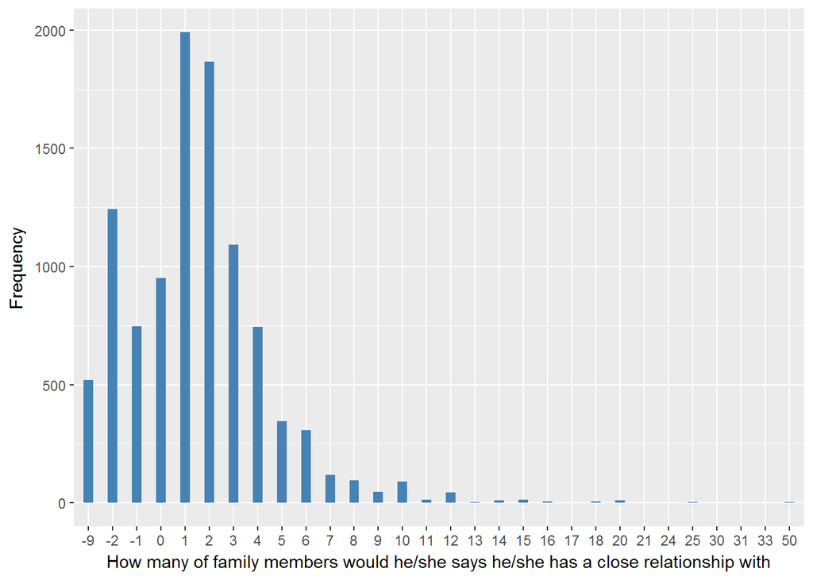

SCCHDM

| Sample size | Missing values |
| --- | --- |
| 10274 | 0 |

Summary

| Min. | 1st Qu. | Median | Mean | 3rd Qu. | Max. |
| --- | --- | --- | --- | --- | --- |
| -9 | -1 | 2 | 0.6673 | 2 | 13 |

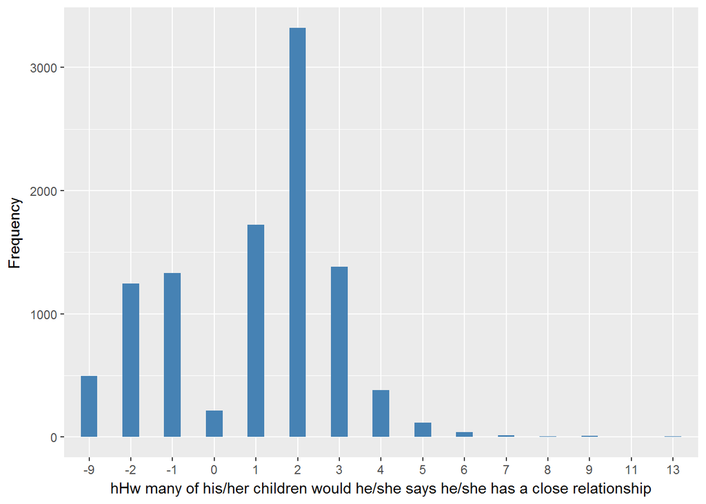

#### 2.1.5.2 Harmonisation algorithm

To recode the harmonize variable from the study-specific variable it has to be recoded as follows:

- `if scfamm>0 and scchdm>0 then clsrel = SUM of scfamm and scchdm`
- `if only one of scfamm or scchdm is >=0 then clsrel is equal to it`
- `if any equals -1 then 996`
- `if any equals -8 then 998`
- `if any equals -9 then 995`
- `NA into 999`

**R script:**

```r
ELSA_ds_w5 <- tibble(id = ELSA_w5_clsrel$id)

ELSA_w5_clsrel$scfamm <- car::recode(as.vector(ELSA_w5_clsrel$scfamm), "NA='-999'")
ELSA_w5_clsrel$scchdm <- car::recode(as.vector(ELSA_w5_clsrel$scchdm), "NA='-999'")

ELSA_ds_w5$clsrel <- c(NA)
for (i in 1:dim(ELSA_w5_clsrel)[1]) {
    if (ELSA_w5_clsrel$scfamm[i] >= 0 & ELSA_w5_clsrel$scchdm[i] >= 0) {
        ELSA_ds_w5$clsrel[i] = ELSA_w5_clsrel$scfamm[i] + ELSA_w5_clsrel$scchdm[i]
    }
    if (ELSA_w5_clsrel$scfamm[i] >= 0 & ELSA_w5_clsrel$scchdm[i] < 0) {
        ELSA_ds_w5$clsrel[i] = ELSA_w5_clsrel$scfamm[i]
    }
    if (ELSA_w5_clsrel$scfamm[i] < 0 & ELSA_w5_clsrel$scchdm[i] >= 0) {
        ELSA_ds_w5$clsrel[i] = ELSA_w5_clsrel$scchdm[i]
    } else if (ELSA_w5_clsrel$scfamm[i] == -1 & ELSA_w5_clsrel$scchdm[i] == -1) {
        ELSA_ds_w5$clsrel[i] = 996
    } else if (ELSA_w5_clsrel$scfamm[i] == -8 & ELSA_w5_clsrel$scchdm[i] == -8) {
        ELSA_ds_w5$clsrel[i] = 998
    } else if (ELSA_w5_clsrel$scfamm[i] == -9 & ELSA_w5_clsrel$scchdm[i] == -9) {
        ELSA_ds_w5$clsrel[i] = 995
    }
}

ELSA_ds_w5$clsrel <- car::recode(as.vector(ELSA_ds_w5$clsrel), "NA='999'")
ELSA_ds_w5$clsrel <- labelled(ELSA_ds_w5$clsrel, labels = c(`lack of friends` = 0,
    Missing = 999, `Do not know` = 998, Refuse = 997, `Not applicable` = 996,
    `Don't answer` = 995, `Not attempt/not done/not yet recorded` = 994, `Disable to measure` = 993,
    Impute = 992, `CAPI/interviewer error` = 991))
```

#### 2.1.5.3 Statistical description of the new harmonised variable

| Sample size | Missing values |
| --- | --- |
| 10274 | 1720 |

Values

|  | No-missings | 991 | 992 | 993 | 994 | 995 | 996 | 997 | 998 | 999 | NA |
| --- | --- | --- | --- | --- | --- | --- | --- | --- | --- | --- | --- |
| Frequency | 8554.00 | 0 | 0 | 0 | 0 | 137.00 | 227.00 | 0 | 0 | 1356.0 | 0 |
| Percentage | 83.26 | 0 | 0 | 0 | 0 | 1.33 | 2.21 | 0 | 0 | 13.2 | 0 |

Summary

| Min. | 1st Qu. | Median | Mean | 3rd Qu. | Max. |
| --- | --- | --- | --- | --- | --- |
| 0 | 2 | 4 | 4.127 | 5 | 59 |

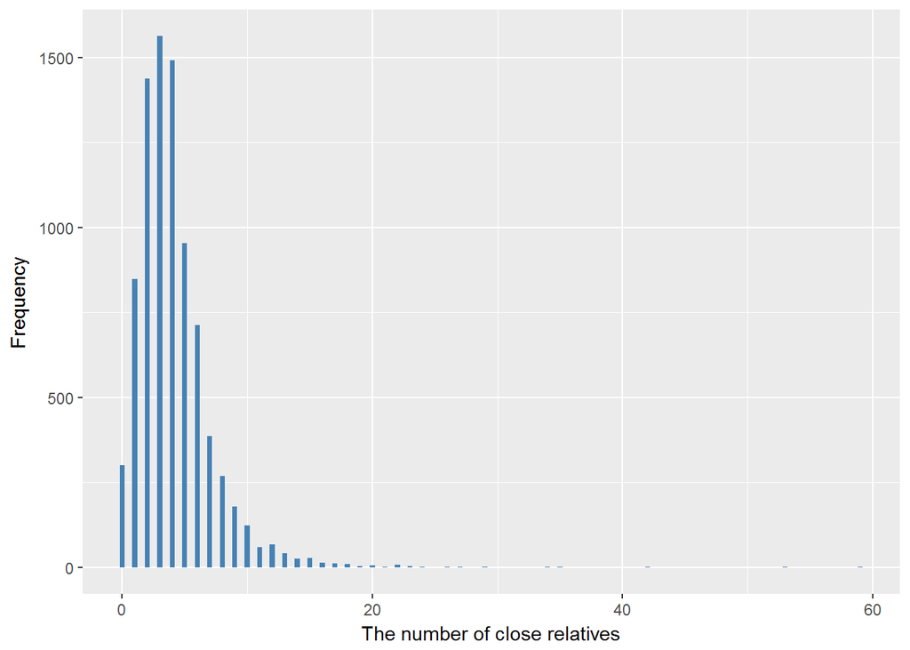

#### 2.1.5.4 Validation

### 2.1.6 Wave 6

#### 2.1.6.1 Study-specific variable description

The study-specific variable elected to be harmonised is:

- Name: `scfamm`
- Label: `how many of these family members would you say you have a close relat`
- Missings:
  - `-9.0 = Not answered`
  - `-8.0 = Don't know`
  - `-1.0 = Item not applicable`
- Name: `scchdm`
- Label: `how many of your children would you say you have a close relationship`
- Missings:
  - `-9.0 = Not answered`
  - `-8.0 = Don't know`
  - `-1.0 = Item not applicable`
- Description:

SCFAMM

| Sample size | Missing values |
| --- | --- |
| 10601 | 0 |

Summary

| Min. | 1st Qu. | Median | Mean | 3rd Qu. | Max. |
| --- | --- | --- | --- | --- | --- |
| -9 | -1 | 1 | 0.7312 | 3 | 55 |

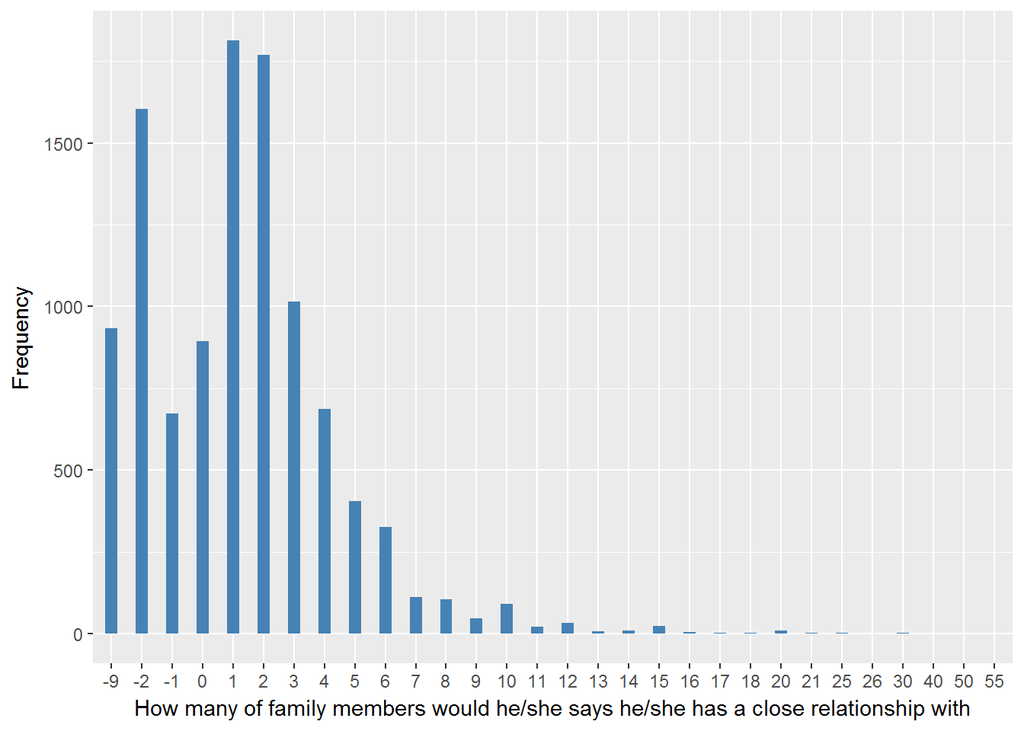

SCCHDM

| Sample size | Missing values |
| --- | --- |
| 10601 | 0 |

Summary

| Min. | 1st Qu. | Median | Mean | 3rd Qu. | Max. |
| --- | --- | --- | --- | --- | --- |
| -9 | -1 | 1 | 0.6087 | 2 | 17 |

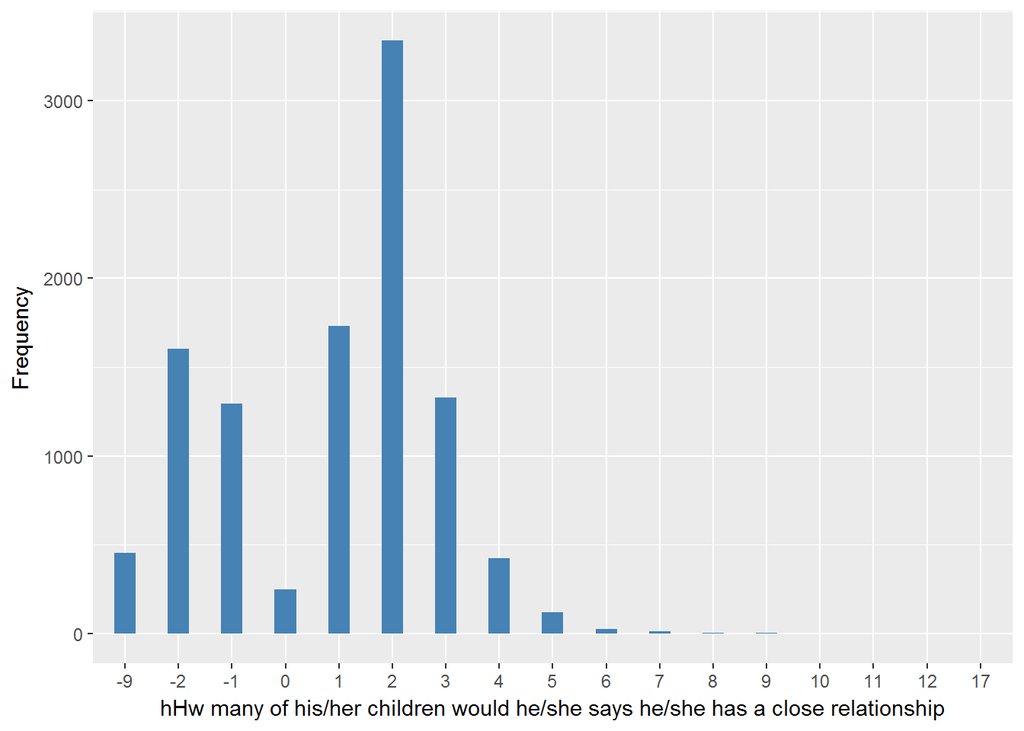

#### 2.1.6.2 Harmonisation algorithm

To recode the harmonize variable from the study-specific variable it has to be recoded as follows:

- `if scfamm>0 and scchdm>0 then clsrel = SUM of scfamm and scchdm`
- `if only one of scfamm or scchdm is >=0 then clsrel is equal to it`
- `if any equals -1 then 996`
- `if any equals -8 then 998`
- `if any equals -9 then 995`
- `NA into 999`

**R script:**

```r
ELSA_ds_w6 <- tibble(id = ELSA_w6_clsrel$id)

ELSA_w6_clsrel$scfamm <- car::recode(as.vector(ELSA_w6_clsrel$scfamm), "NA='-999'")
ELSA_w6_clsrel$scchdm <- car::recode(as.vector(ELSA_w6_clsrel$scchdm), "NA='-999'")

ELSA_ds_w6$clsrel <- c(NA)
for (i in 1:dim(ELSA_w6_clsrel)[1]) {
    if (ELSA_w6_clsrel$scfamm[i] >= 0 & ELSA_w6_clsrel$scchdm[i] >= 0) {
        ELSA_ds_w6$clsrel[i] = ELSA_w6_clsrel$scfamm[i] + ELSA_w6_clsrel$scchdm[i]
    }
    if (ELSA_w6_clsrel$scfamm[i] >= 0 & ELSA_w6_clsrel$scchdm[i] < 0) {
        ELSA_ds_w6$clsrel[i] = ELSA_w6_clsrel$scfamm[i]
    }
    if (ELSA_w6_clsrel$scfamm[i] < 0 & ELSA_w6_clsrel$scchdm[i] >= 0) {
        ELSA_ds_w6$clsrel[i] = ELSA_w6_clsrel$scchdm[i]
    } else if (ELSA_w6_clsrel$scfamm[i] == -1 & ELSA_w6_clsrel$scchdm[i] == -1) {
        ELSA_ds_w6$clsrel[i] = 996
    } else if (ELSA_w6_clsrel$scfamm[i] == -8 & ELSA_w6_clsrel$scchdm[i] == -8) {
        ELSA_ds_w6$clsrel[i] = 998
    } else if (ELSA_w6_clsrel$scfamm[i] == -9 & ELSA_w6_clsrel$scchdm[i] == -9) {
        ELSA_ds_w6$clsrel[i] = 995
    }
}

ELSA_ds_w6$clsrel <- car::recode(as.vector(ELSA_ds_w6$clsrel), "NA='999'")
ELSA_ds_w6$clsrel <- labelled(ELSA_ds_w6$clsrel, labels = c(`lack of friends` = 0,
    Missing = 999, `Do not know` = 998, Refuse = 997, `Not applicable` = 996,
    `Don't answer` = 995, `Not attempt/not done/not yet recorded` = 994, `Disable to measure` = 993,
    Impute = 992, `CAPI/interviewer error` = 991))
```

#### 2.1.6.3 Statistical description of the new harmonised variable

| Sample size | Missing values |
| --- | --- |
| 10601 | 2097 |

Values

|  | No-missings | 991 | 992 | 993 | 994 | 995 | 996 | 997 | 998 | 999 | NA |
| --- | --- | --- | --- | --- | --- | --- | --- | --- | --- | --- | --- |
| Frequency | 8504.00 | 0 | 0 | 0 | 0 | 179.00 | 167.00 | 0 | 0 | 1751.00 | 0 |
| Percentage | 80.22 | 0 | 0 | 0 | 0 | 1.69 | 1.58 | 0 | 0 | 16.52 | 0 |

Summary

| Min. | 1st Qu. | Median | Mean | 3rd Qu. | Max. |
| --- | --- | --- | --- | --- | --- |
| 0 | 2 | 4 | 4.128 | 5 | 59 |

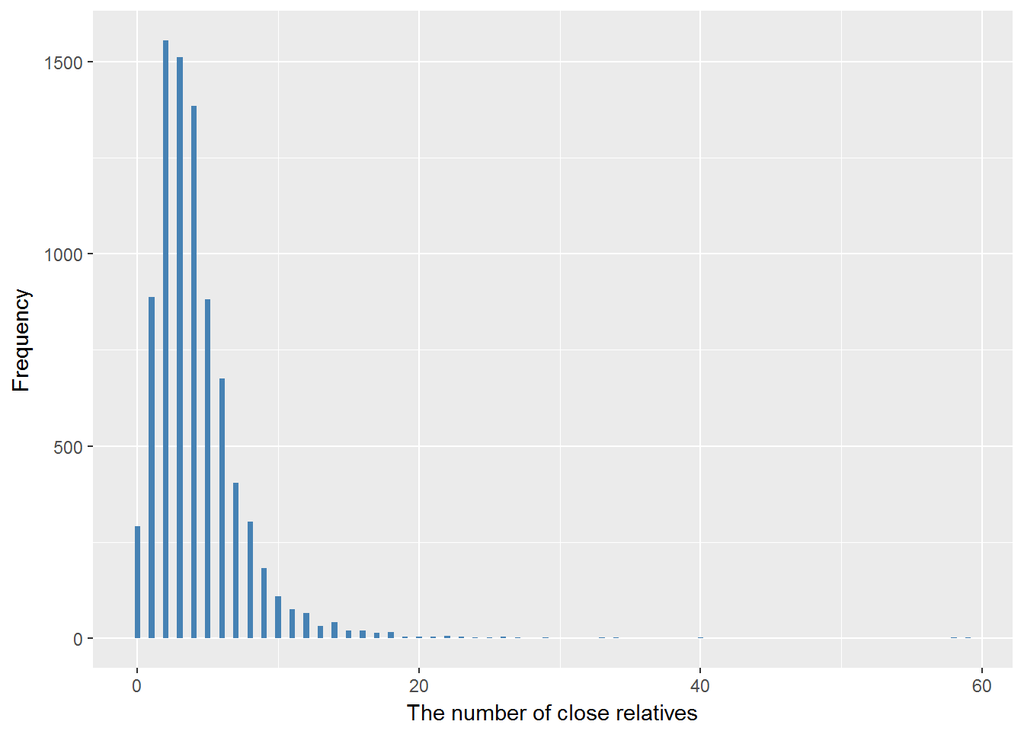

#### 2.1.6.4 Validation

### 2.1.7 Wave 7

#### 2.1.7.1 Study-specific variable description

The study-specific variable elected to be harmonised is:

- Name: `scfaml`
- Label: `how many of these family members would you say you have a close relat`
- Missings:
  - `-9 = Not answered`
  - `-8 = Don't know`
  - `-2 = Schedule not applicable`
  - `-1 = Item not applicable`
- Name: `scchdm`
- Label: `how many of your children would you say you have a close relationship`
- Missings:
  - `-9 = Not answered`
  - `-8 = Don't know`
  - `-2 = Schedule not applicable`
  - `-1 = Item not applicable`
- Description:

| Sample size | Missing values |
| --- | --- |
| 9666 | 2695 |

Summary

| Min. | 1st Qu. | Median | Mean | 3rd Qu. | Max. |
| --- | --- | --- | --- | --- | --- |
| 0 | 1 | 2 | 2.788 | 4 | 75 |

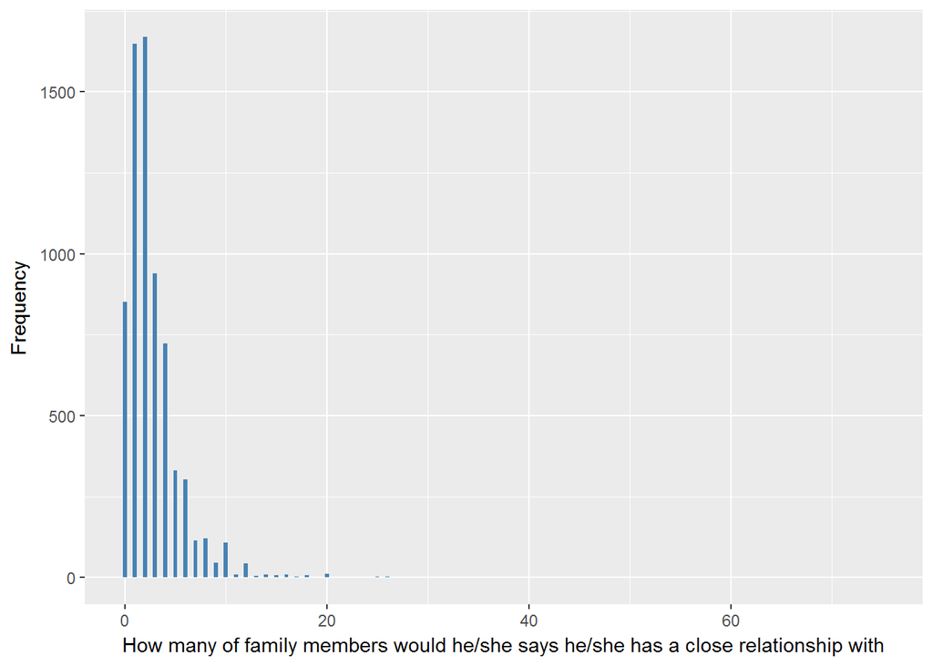

| Sample size | Missing values |
| --- | --- |
| 9666 | 3703 |

Summary

| Min. | 1st Qu. | Median | Mean | 3rd Qu. | Max. |
| --- | --- | --- | --- | --- | --- |
| 0 | 1 | 2 | 2.075 | 3 | 12 |

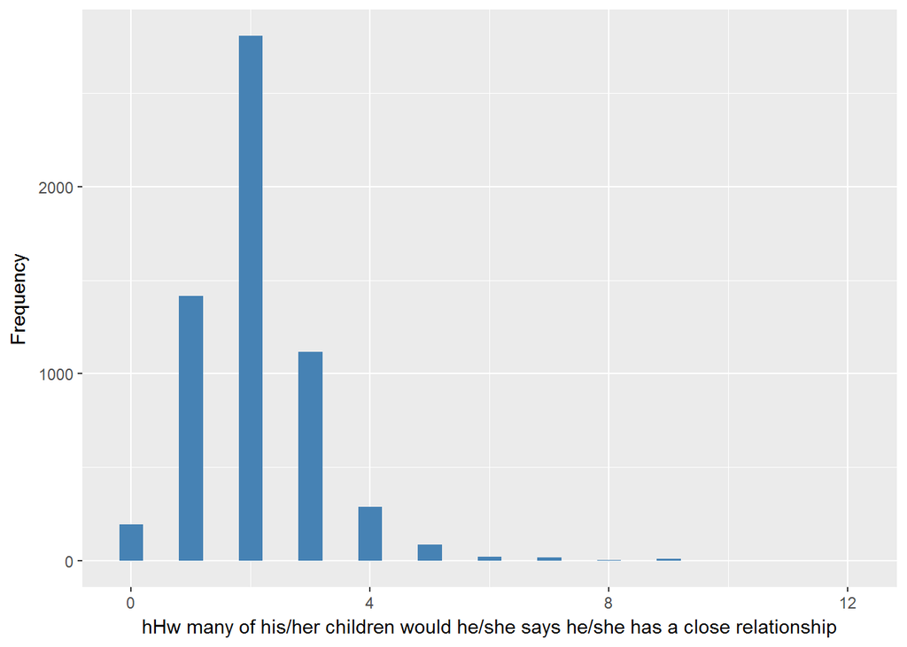

#### 2.1.7.2 Harmonisation algorithm

To recode the harmonize variable from the study-specific variable it has to be recoded as follows:

- `if scfaml>0 and scchdm>0 then clsrel = SUM of scfaml and scchdm`
- `if only one of scfaml or scchdm is >=0 then clsrel is equal to it`
- `if any equals -1 then 996`
- `if any equals -8 then 998`
- `if any equals -9 then 995`
- `NA into 999`

**R script:**

```r
ELSA_ds_w7 <- tibble(id = ELSA_w7$id)

ELSA_w7$scfaml <- car::recode(as.vector(ELSA_w7$scfaml), "NA='-999'")
ELSA_w7$scchdm <- car::recode(as.vector(ELSA_w7$scchdm), "NA='-999'")

ELSA_ds_w7$clsrel <- c(NA)
for (i in 1:dim(ELSA_w7)[1]) {
    if (ELSA_w7$scfaml[i] >= 0 & ELSA_w7$scchdm[i] >= 0) {
        ELSA_ds_w7$clsrel[i] = ELSA_w7$scfaml[i] + ELSA_w7$scchdm[i]
    }
    if (ELSA_w7$scfaml[i] >= 0 & ELSA_w7$scchdm[i] < 0) {
        ELSA_ds_w7$clsrel[i] = ELSA_w7$scfaml[i]
    }
    if (ELSA_w7$scfaml[i] < 0 & ELSA_w7$scchdm[i] >= 0) {
        ELSA_ds_w7$clsrel[i] = ELSA_w7$scchdm[i]
    } else if (ELSA_w7$scfaml[i] == -1 & ELSA_w7$scchdm[i] == -1) {
        ELSA_ds_w7$clsrel[i] = 996
    } else if (ELSA_w7$scfaml[i] == -8 & ELSA_w7$scchdm[i] == -8) {
        ELSA_ds_w7$clsrel[i] = 998
    } else if (ELSA_w7$scfaml[i] == -9 & ELSA_w7$scchdm[i] == -9) {
        ELSA_ds_w7$clsrel[i] = 995
    }
}

ELSA_ds_w7$clsrel <- car::recode(as.vector(ELSA_ds_w7$clsrel), "NA='999'")
ELSA_ds_w7$clsrel <- labelled(ELSA_ds_w7$clsrel, labels = c(`lack of friends` = 0,
    Missing = 999, `Do not know` = 998, Refuse = 997, `Not applicable` = 996,
    `Don't answer` = 995, `Not attempt/not done/not yet recorded` = 994, `Disable to measure` = 993,
    Impute = 992, `CAPI/interviewer error` = 991))
```

#### 2.1.7.3 Statistical description of the new harmonised variable

| Sample size | Missing values |
| --- | --- |
| 9666 | 2043 |

Values

|  | No-missings | 991 | 992 | 993 | 994 | 995 | 996 | 997 | 998 | 999 | NA |
| --- | --- | --- | --- | --- | --- | --- | --- | --- | --- | --- | --- |
| Frequency | 7623.00 | 0 | 0 | 0 | 0 | 243.00 | 182.00 | 0 | 0 | 1618.00 | 0 |
| Percentage | 78.86 | 0 | 0 | 0 | 0 | 2.51 | 1.88 | 0 | 0 | 16.74 | 0 |

Summary

| Min. | 1st Qu. | Median | Mean | 3rd Qu. | Max. |
| --- | --- | --- | --- | --- | --- |
| 0 | 2 | 4 | 4.173 | 5 | 78 |

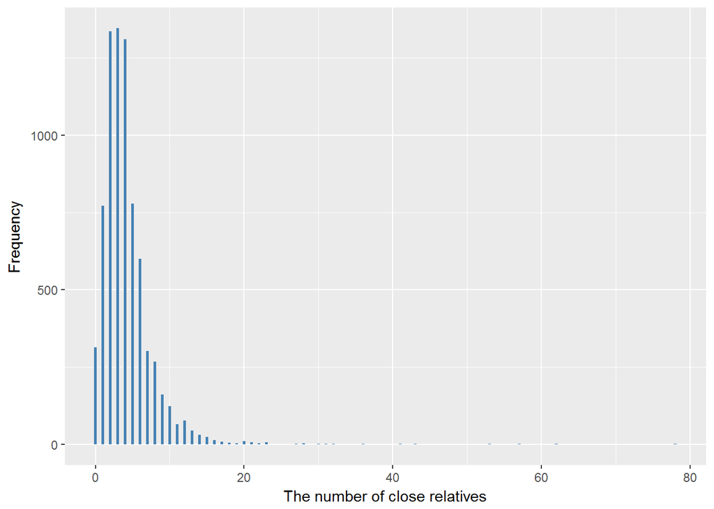

#### 2.1.7.4 Validation

# 3 Quality estimation